# DM_Project

### Marital.Status

```r
# Marital.Status with CLV:
pivot(data = Insurance_df, compute = c(mean,sum), variable = Customer.Lifetime.Value, by = Marital.Status )
```

```
##   Marital.Status Customer.Lifetime.Value_n Customer.Lifetime.Value_na
## 1       Divorced                      1369                          0
## 2        Married                      5298                          0
## 3         Single                      2467                          0
##   Customer.Lifetime.Value_mean Customer.Lifetime.Value_sum
## 1                     8241.239                    11282256
## 2                     8078.967                    42802367
## 3                     7714.837                    19032503
```

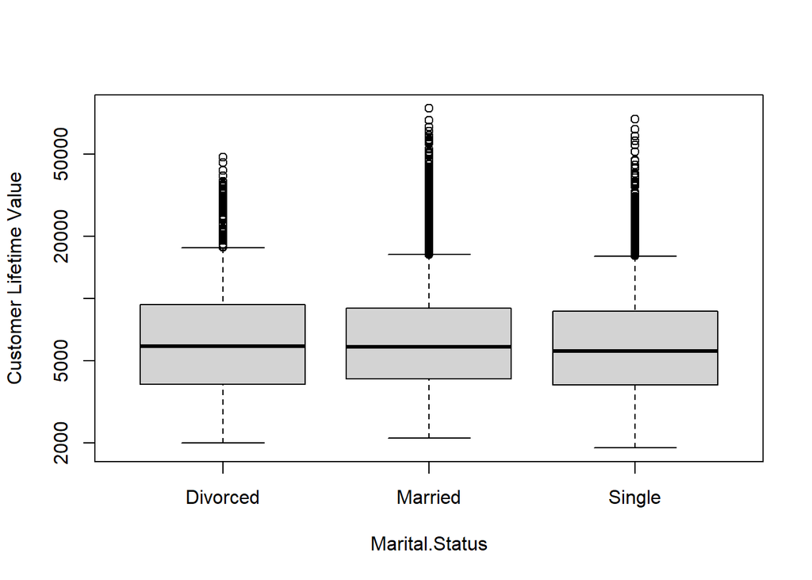

```r
boxplot(Insurance_df$Customer.Lifetime.Value ~ Insurance_df$Marital.Status, xlab = "Marital.Status", ylab = "Customer Lifetime Value", log = 'y' )
```

```r
# Marital.Status with Response:
Insurance_df %>%
  count(Response, Marital.Status) #Pivot table for Response and Marital.Status
```

```
##   Response Marital.Status    n
## 1       No       Divorced 1045
## 2       No        Married 4602
## 3       No         Single 2179
## 4      Yes       Divorced  324
## 5      Yes        Married  696
## 6      Yes         Single  288
```

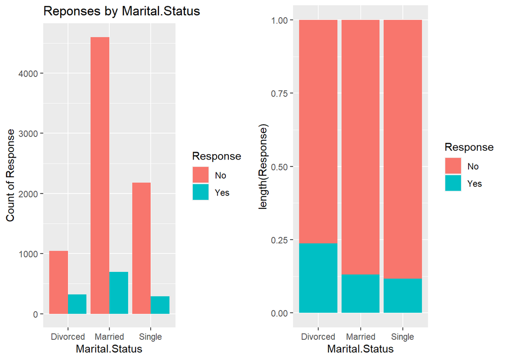

```r
Marital.Status.Plot1 <- ggplot(Insurance_df, aes(x = Marital.Status, fill = Response)) +
  geom_bar(position = "dodge") + labs(y="Count of Response",title="Reponses by Marital.Status")

Marital.Status.Plot2 <-ggplot(Insurance_df, aes(x = Marital.Status, y = length(Response), fill = Response)) +
  geom_col(position = "fill")  #Proportion between YES and NO
grid.arrange(Marital.Status.Plot1, Marital.Status.Plot2, ncol=2)
```

- We can see from the boxplot and pivot table of CLV and Marital.Status, the CLV of Divorced, Married, and Single customer are same.
- The YES response ratio of Divorced customer is higher than that of Married and Single Customer.

### Num.of.Complaints

```r
# Num.of.Complaints with CLV:
pivot(data = Insurance_df, compute = c(mean,sum), variable = Customer.Lifetime.Value, by = Num.of.Complaints )
```

```
##   Num.of.Complaints Customer.Lifetime.Value_n Customer.Lifetime.Value_na
## 1       Less than 3                      8637                          0
## 2       More than 3                       497                          0
##   Customer.Lifetime.Value_mean Customer.Lifetime.Value_sum
## 1                     8076.001                    69752421
## 2                     6770.030                     3364705
```

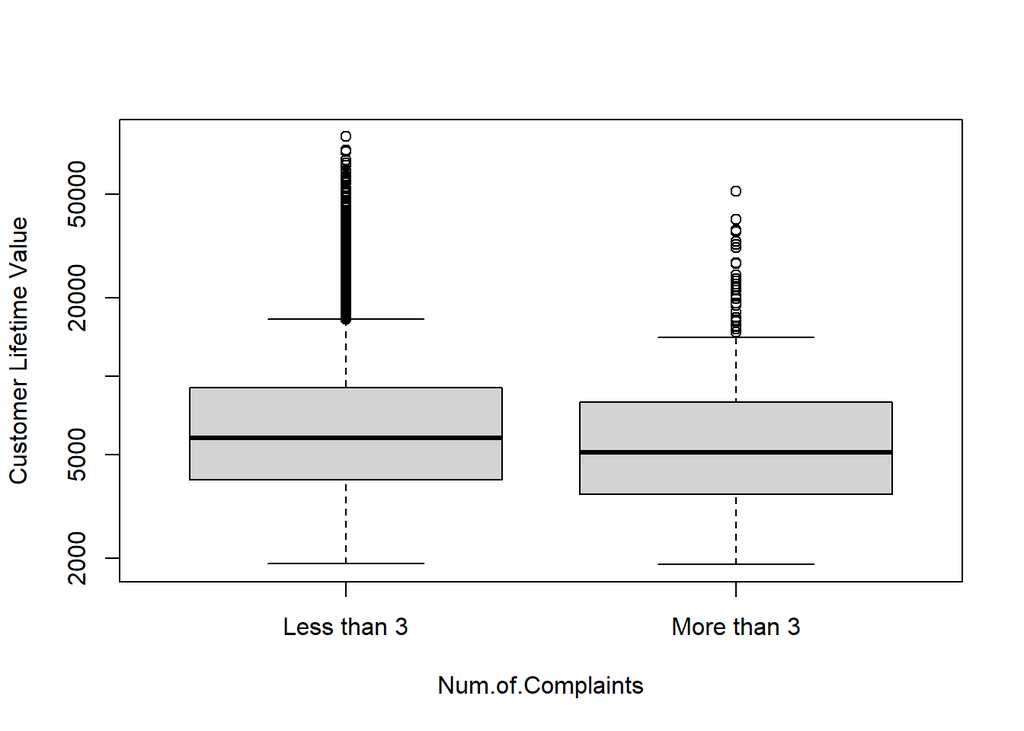

```r
boxplot(Insurance_df$Customer.Lifetime.Value ~ Insurance_df$Num.of.Complaints, xlab = "Num.of.Complaints", ylab = "Customer Lifetime Value", log = 'y' )
```

```r
# Num.of.Complaints with Response:
Insurance_df %>%
  count(Response, Num.of.Complaints) #Pivot table for Response and Num.of.Complaints
```

```
##   Response Num.of.Complaints    n
## 1       No       Less than 3 7413
## 2       No       More than 3  413
## 3      Yes       Less than 3 1224
## 4      Yes       More than 3   84
```

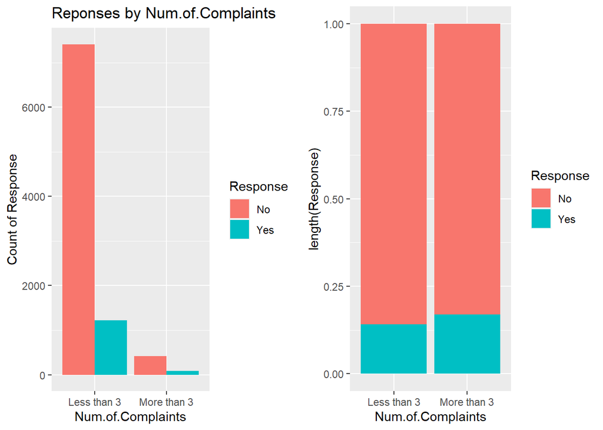

```r
Num.of.Complaints.Plot1 <- ggplot(Insurance_df, aes(x = Num.of.Complaints, fill = Response)) +
  geom_bar(position = "dodge") + labs(y="Count of Response",title="Reponses by Num.of.Complaints")

Num.of.Complaints.Plot2 <-ggplot(Insurance_df, aes(x = Num.of.Complaints, y = length(Response), fill = Response)) +
  geom_col(position = "fill")  #Proportion between YES and NO
grid.arrange(Num.of.Complaints.Plot1, Num.of.Complaints.Plot2, ncol=2)
```

- We can see from the boxplot and pivot table of CLV and Num.of.Complaints, Customers who make less than 3 complaints make much more CLV than customers make more than 3 complaints.
- But the ratio of saying YES of customers make more than 3 complaints is higher.

### New.Num.of.Policies

```r
# New.Num.of.Policies with CLV:
pivot(data = Insurance_df, compute = c(mean,sum), variable = Customer.Lifetime.Value, by = New.Num.of.Policies )
```

```
##   New.Num.of.Policies Customer.Lifetime.Value_n Customer.Lifetime.Value_na
## 1                   1                      3251                          0
## 2                   2                      2294                          0
## 3         More than 2                      3589                          0
##   Customer.Lifetime.Value_mean Customer.Lifetime.Value_sum
## 1                     3606.955                    11726211
## 2                    15723.178                    36068970
## 3                     7055.432                    25321945
```

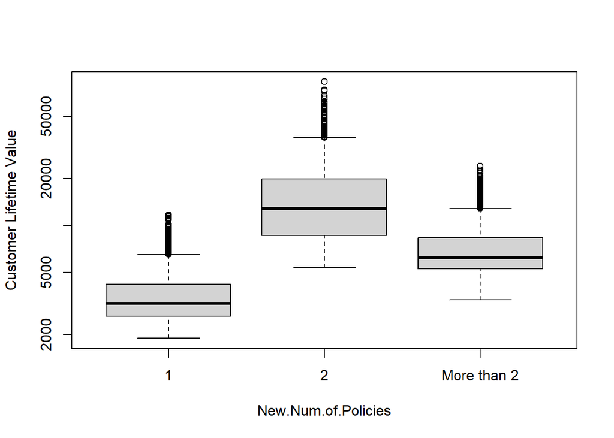

```r
boxplot(Insurance_df$Customer.Lifetime.Value ~ Insurance_df$New.Num.of.Policies, xlab = "New.Num.of.Policies", ylab = "Customer Lifetime Value", log = 'y' )
```

```r
# New.Num.of.Policies with Response:
Insurance_df %>%
  count(Response, New.Num.of.Policies) #Pivot table for Response and New.Num.of.Policies
```

```
##   Response New.Num.of.Policies    n
## 1       No                   1 2735
## 2       No                   2 1952
## 3       No         More than 2 3139
## 4      Yes                   1  516
## 5      Yes                   2  342
## 6      Yes         More than 2  450
```

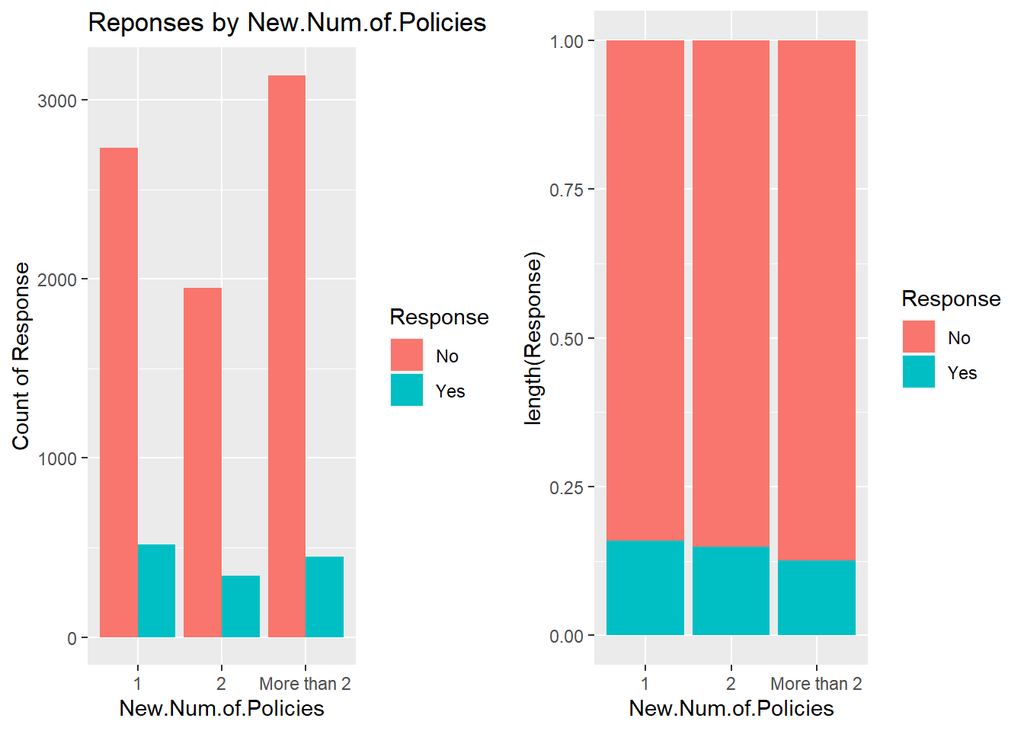

```r
Num.of.Policy.Plot1 <- ggplot(Insurance_df, aes(x = New.Num.of.Policies, fill = Response)) +
  geom_bar(position = "dodge") + labs(y="Count of Response",title="Reponses by New.Num.of.Policies")

Num.of.Policy.Plot2 <-ggplot(Insurance_df, aes(x = New.Num.of.Policies, y = length(Response), fill = Response)) +
  geom_col(position = "fill")  #Proportion between YES and NO
grid.arrange(Num.of.Policy.Plot1, Num.of.Policy.Plot2, ncol=2)
```

- We can see from the boxplot and pivot table of CLV and New.Num.of.Policies, Customers who buy 2 policies make much more CLV than other customers. Customers who buy only 1 policy has lowest CLV
- But the ratio of saying YES of customers buying 1 policy is higher than others.

### Policy.Type

```r
# Policy Type with CLV:
pivot(data = Insurance_df, compute = c(mean,sum), variable = Customer.Lifetime.Value, by = Policy.Type )
```

```
##      Policy.Type Customer.Lifetime.Value_n Customer.Lifetime.Value_na
## 1 Corporate Auto                      1968                          0
## 2  Personal Auto                      6788                          0
## 3   Special Auto                       378                          0
##   Customer.Lifetime.Value_mean Customer.Lifetime.Value_sum
## 1                     7814.410                    15378758
## 2                     8027.364                    54489744
## 3                     8594.245                     3248625
```

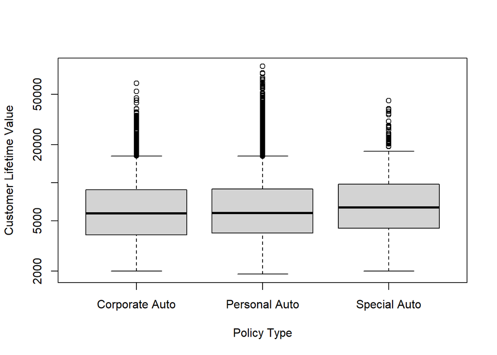

```r
boxplot(Insurance_df$Customer.Lifetime.Value ~ Insurance_df$Policy.Type, xlab = "Policy Type", ylab = "Customer Lifetime Value", log = 'y' )
```

```r
# Policy Type with Response:
Insurance_df %>%
  count(Response,Policy.Type) #Pivot table for Response and Coverage
```

```
##   Response    Policy.Type    n
## 1       No Corporate Auto 1680
## 2       No  Personal Auto 5830
## 3       No   Special Auto  316
## 4      Yes Corporate Auto  288
## 5      Yes  Personal Auto  958
## 6      Yes   Special Auto   62
```

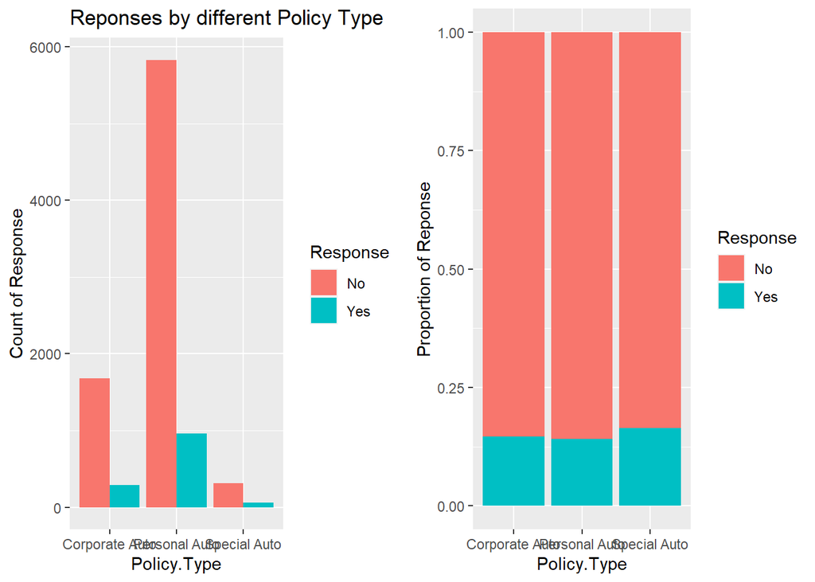

```r
Policy.Plot1 <- ggplot(Insurance_df, aes(x = Policy.Type, fill = Response)) +
  geom_bar(position = "dodge")+labs(y="Count of Response",title="Reponses by different Policy Type")

Policy.Plot2 <-ggplot(Insurance_df, aes(x = Policy.Type, y = length(Response), fill = Response)) +
  geom_col(position = "fill") +labs (y="Proportion of Reponse") #Proportion between YES and NO
grid.arrange(Policy.Plot1, Policy.Plot2, ncol=2)
```

The plot shows Customers who have Special Policy have highest range of livetime value, but overall there is not much difference between different types of policy to customer lifetime value.

The barchart shows most of customers are taking Personal Auto. Response “No” also accounts for majority, the proportion of Yes in Special Auto is a little higher than other two type.

### Renew.Offer.Type

```r
# Renew Offer Type with CLV:
pivot(data = Insurance_df, compute = c(mean,sum), variable = Customer.Lifetime.Value, by = Renew.Offer.Type )
```

```
##   Renew.Offer.Type Customer.Lifetime.Value_n Customer.Lifetime.Value_na
## 1           Offer1                      3752                          0
## 2           Offer2                      2926                          0
## 3           Offer3                      1432                          0
## 4           Offer4                      1024                          0
##   Customer.Lifetime.Value_mean Customer.Lifetime.Value_sum
## 1                     8707.086                    32668985
## 2                     7396.754                    21642902
## 3                     7997.887                    11452973
## 4                     7179.947                     7352266
```

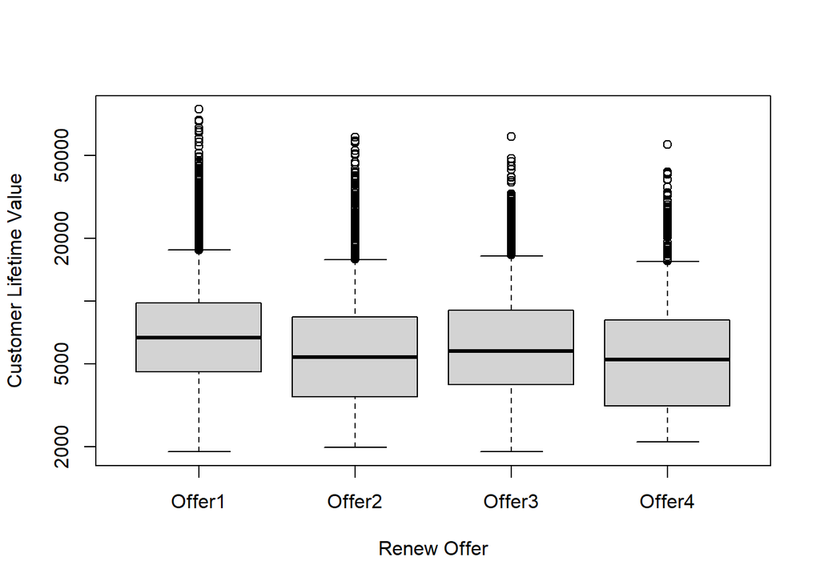

```r
boxplot(Insurance_df$Customer.Lifetime.Value ~ Insurance_df$Renew.Offer.Type, xlab = "Renew Offer", ylab = "Customer Lifetime Value", log = 'y' )
```

```r
# Renew Offer Type with Response:
Insurance_df %>%
  count(Response,Renew.Offer.Type) #Pivot table for Response and Coverage
```

```
##   Response Renew.Offer.Type    n
## 1       No           Offer1 3158
## 2       No           Offer2 2242
## 3       No           Offer3 1402
## 4       No           Offer4 1024
## 5      Yes           Offer1  594
## 6      Yes           Offer2  684
## 7      Yes           Offer3   30
```

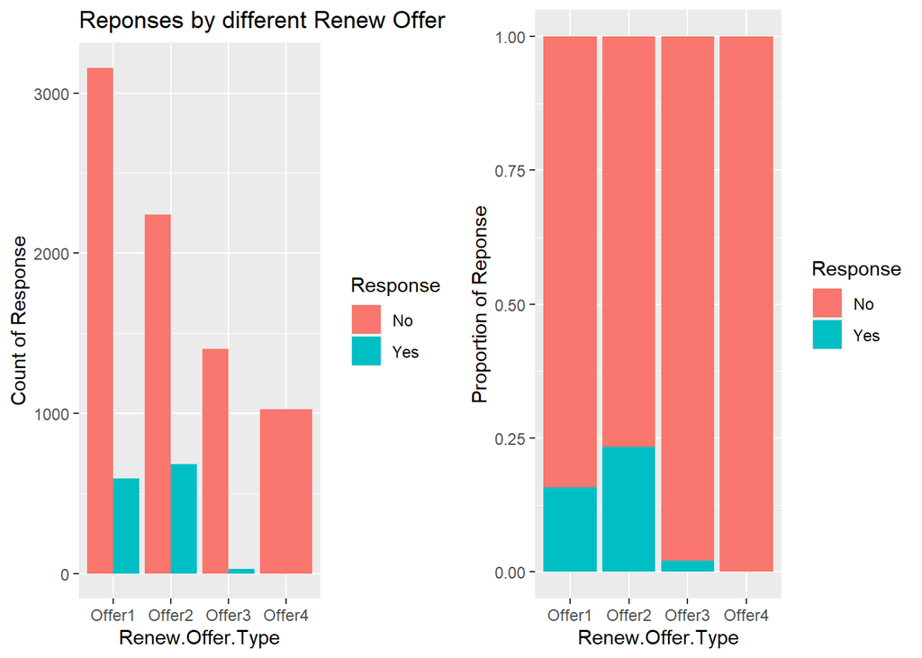

```r
Renew.Plot1 <- ggplot(Insurance_df, aes(x = Renew.Offer.Type, fill = Response)) +
  geom_bar(position = "dodge")+labs(y="Count of Response",title="Reponses by different Renew Offer")

Renew.Plot2 <-ggplot(Insurance_df, aes(x = Renew.Offer.Type, y = length(Response), fill = Response)) +
  geom_col(position = "fill") +labs (y="Proportion of Reponse") #Proportion between YES and NO
grid.arrange(Renew.Plot1, Renew.Plot2, ncol=2)
```

The boxplot shows customers who receive Offer 1 have highest lifetime value, and those who receive Offer 4 have lowest value. The charts show that most of customer reponsed Yes received offer 1 and 2, and there is little accept offer 3 and no customer accept offer 4. Propotion of response yes is highest for offer 2 and equal 0 for offer 4.

### Vehicle.Class

```r
# Vehicle Class with CLV:
pivot(data = Insurance_df, compute = c(mean,sum), variable = Customer.Lifetime.Value, by = Vehicle.Class)
```

```
##   Vehicle.Class Customer.Lifetime.Value_n Customer.Lifetime.Value_na
## 1 Four-Door Car                      4621                          0
## 2    Luxury Car                       163                          0
## 3    Luxury SUV                       184                          0
## 4    Sports Car                       484                          0
## 5           SUV                      1796                          0
## 6  Two-Door Car                      1886                          0
##   Customer.Lifetime.Value_mean Customer.Lifetime.Value_sum
## 1                     6631.727                    30645209
## 2                    17053.348                     2779696
## 3                    17122.999                     3150632
## 4                    10750.989                     5203479
## 5                    10443.512                    18756547
## 6                     6671.031                    12581564
```

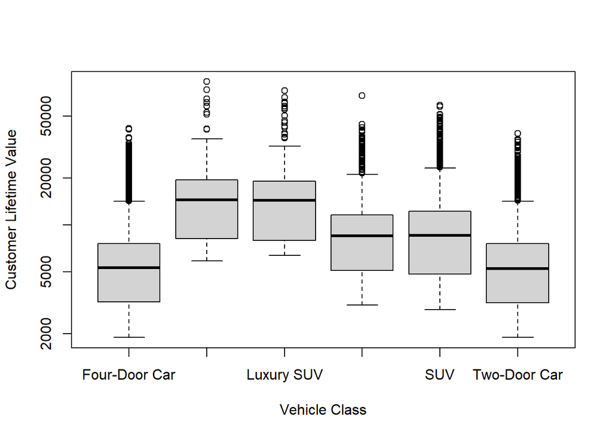

```r
boxplot(Insurance_df$Customer.Lifetime.Value ~ Insurance_df$Vehicle.Class, xlab = "Vehicle Class", ylab = "Customer Lifetime Value", log = 'y' )
```

```r
# Vehicle Class with Response:
Insurance_df %>%
  count(Response,Vehicle.Class) #Pivot table for Response and Vehicle Class
```

```
##    Response Vehicle.Class    n
## 1        No Four-Door Car 3997
## 2        No    Luxury Car  151
## 3        No    Luxury SUV  154
## 4        No    Sports Car  394
## 5        No           SUV 1508
## 6        No  Two-Door Car 1622
## 7       Yes Four-Door Car  624
## 8       Yes    Luxury Car   12
## 9       Yes    Luxury SUV   30
## 10      Yes    Sports Car   90
## 11      Yes           SUV  288
## 12      Yes  Two-Door Car  264
```

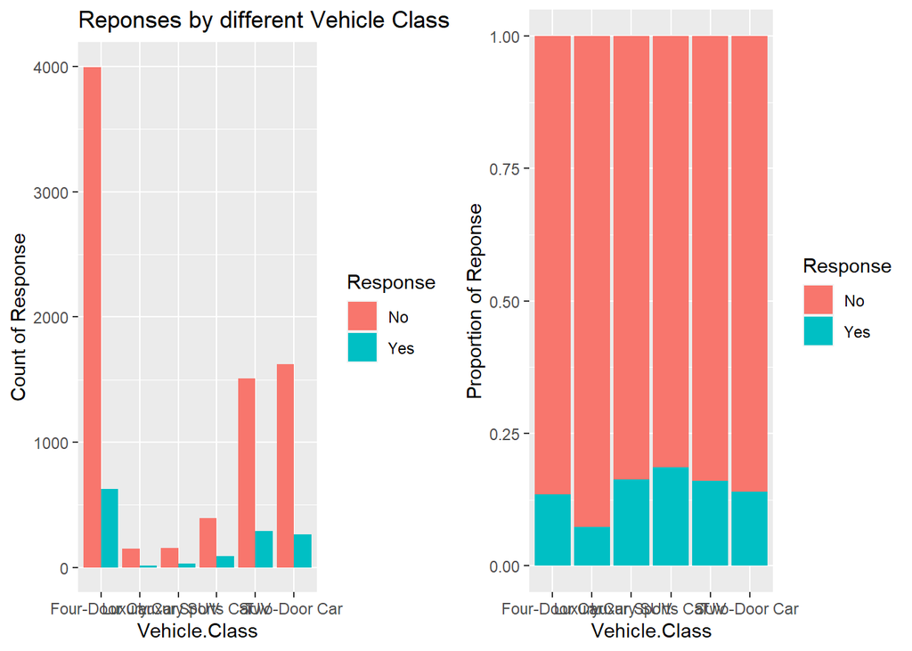

```r
VehicleClass.Plot1 <- ggplot(Insurance_df, aes(x = Vehicle.Class, fill = Response)) +
  geom_bar(position = "dodge")+labs(y="Count of Response",title="Reponses by different Vehicle Class")

VehicleClass.Plot2 <-ggplot(Insurance_df, aes(x = Vehicle.Class, y = length(Response), fill = Response)) +
  geom_col(position = "fill") +labs (y="Proportion of Reponse") #Proportion between YES and NO
grid.arrange(VehicleClass.Plot1, VehicleClass.Plot2, ncol=2)
```

```r
# Bacause the effects of Luxury car and Luxury SUV on CLV are quite similar, we could group 2 types of car into a group called "Luxury Vehicle".
# Similarly, we could group Sport Car and SUV into group called "Mid.Class Vehicle", Four-Door Car and Two-Door Car we could group into "Normal Vehicle"
Insurance_df$New.Car.Class = ifelse(Insurance_df$Vehicle.Class %in% c("Luxury Car","Luxury SUV"),"Luxury Vehicle",
                                    ifelse(Insurance_df$Vehicle.Class %in% c("Sports Car","SUV"),"Mid.Class Vehicle","Normal Vehicle"))
```

The plot shows customers with four-door car and two-door car have lowest customer life time value, while customers with Luxury Car and Luxury SUV have highest value. The charts show most of customer own a four-door car, least of customer own Luxury car, response of Yes is seen similarly. Customers owning an Sport car have highest probibality of accept renewal offer, while those owning an Luxury car have lowest probability of Yes response.

### Sales.Channel

```r
# Sales Channel with CLV:
pivot(data = Insurance_df, compute = c(mean,sum), variable = Customer.Lifetime.Value, by = Sales.Channel)
```

```
##   Sales.Channel Customer.Lifetime.Value_n Customer.Lifetime.Value_na
## 1         Agent                      3477                          0
## 2        Branch                      2567                          0
## 3   Call Center                      1765                          0
## 4           Web                      1325                          0
##   Customer.Lifetime.Value_mean Customer.Lifetime.Value_sum
## 1                     7957.709                    27668955
## 2                     8119.712                    20843300
## 3                     8100.086                    14296651
## 4                     7779.788                    10308219
```

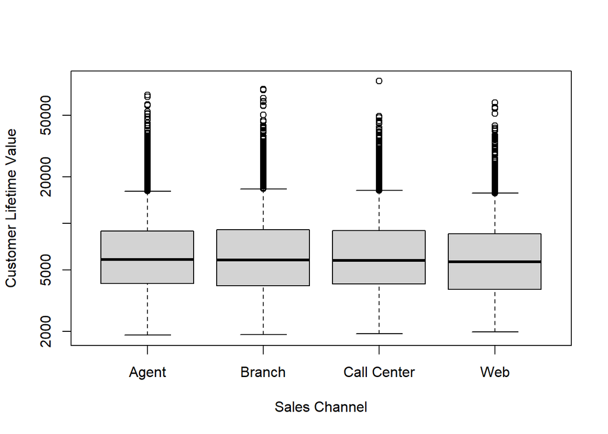

```r
boxplot(Insurance_df$Customer.Lifetime.Value ~ Insurance_df$Sales.Channel, xlab = "Sales Channel", ylab = "Customer Lifetime Value", log = 'y' )
```

```r
# Sales Channel with Response:
Insurance_df %>%
  count(Response,Sales.Channel) #Pivot table for Response and Sales Channel
```

```
##   Response Sales.Channel    n
## 1       No         Agent 2811
## 2       No        Branch 2273
## 3       No   Call Center 1573
## 4       No           Web 1169
## 5      Yes         Agent  666
## 6      Yes        Branch  294
## 7      Yes   Call Center  192
## 8      Yes           Web  156
```

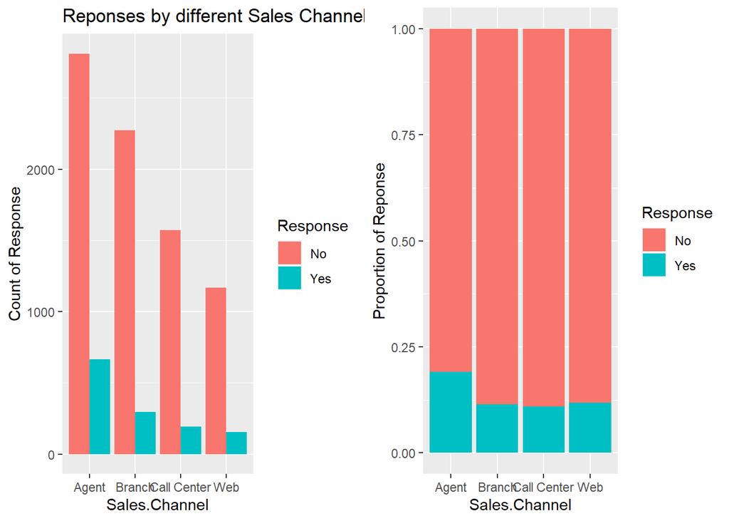

```r
Channel.Plot1 <- ggplot(Insurance_df, aes(x = Sales.Channel, fill = Response)) +
  geom_bar(position = "dodge")+labs(y="Count of Response",title="Reponses by different Sales Channel")

Channel.Plot2 <-ggplot(Insurance_df, aes(x = Sales.Channel, y = length(Response), fill = Response)) +
  geom_col(position = "fill") +labs (y="Proportion of Reponse") #Proportion between YES and NO
grid.arrange(Channel.Plot1, Channel.Plot2, ncol=2)
```

The plot shows customer lifetime values through web channel is lowest, but overall there are not much difference. The chart shows most of customers buying insurance and accept renewal offer via Agent and a few buying and renew via web. Propotion of Yes via Agent is highest, while others three channel is quite similar.

### Vehicle.Size

```r
# Vehicle Size with CLV:
pivot(data = Insurance_df, compute = c(mean,sum), variable = Customer.Lifetime.Value, by = Vehicle.Size)
```

```
##   Vehicle.Size Customer.Lifetime.Value_n Customer.Lifetime.Value_na
## 1        Large                       946                          0
## 2      Medsize                      6424                          0
## 3        Small                      1764                          0
##   Customer.Lifetime.Value_mean Customer.Lifetime.Value_sum
## 1                     7544.996                     7137566
## 2                     8050.662                    51717451
## 3                     8085.096                    14262109
```

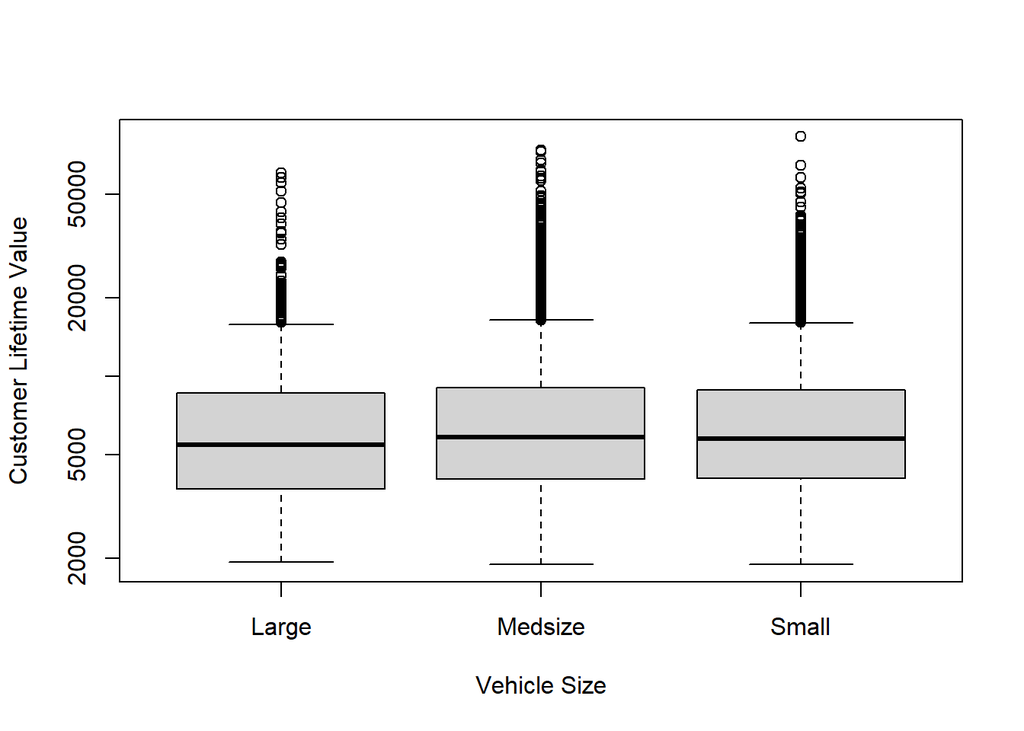

```r
boxplot(Insurance_df$Customer.Lifetime.Value ~ Insurance_df$Vehicle.Size, xlab = "Vehicle Size", ylab = "Customer Lifetime Value", log = 'y' )
```

```r
# Vehicle Size with Response:
Insurance_df %>%
  count(Response,Vehicle.Size) #Pivot table for Response and Vehicle Size
```

```
##   Response Vehicle.Size    n
## 1       No        Large  778
## 2       No      Medsize 5482
## 3       No        Small 1566
## 4      Yes        Large  168
## 5      Yes      Medsize  942
## 6      Yes        Small  198
```

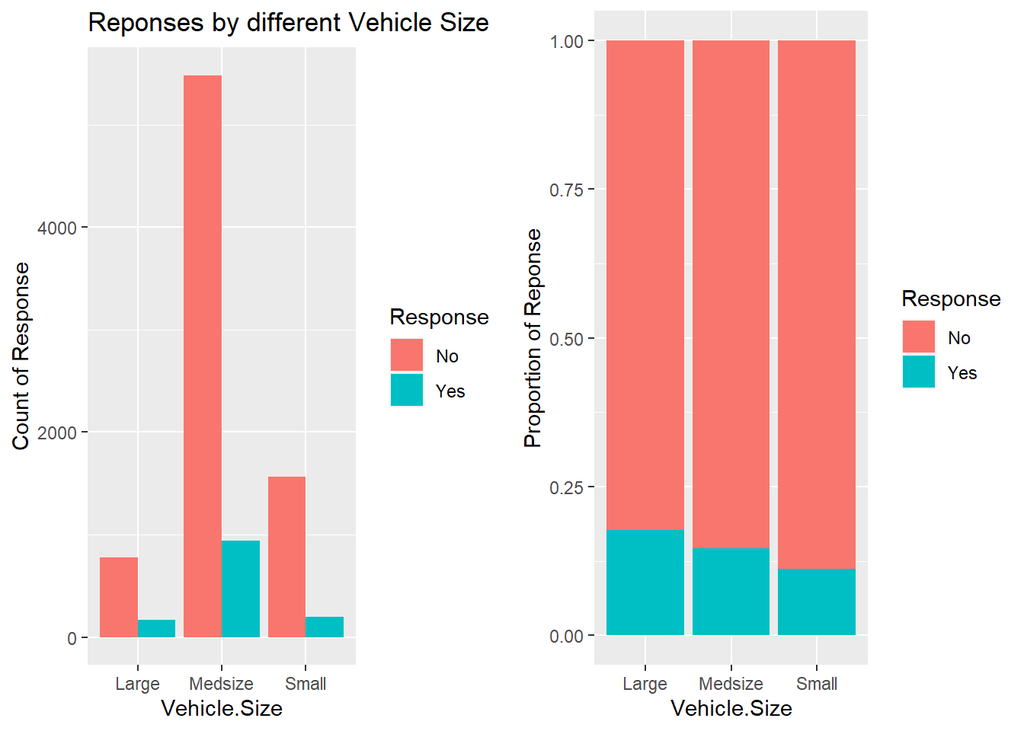

```r
VehicleSize.Plot1 <- ggplot(Insurance_df, aes(x = Vehicle.Size, fill = Response)) +
  geom_bar(position = "dodge")+labs(y="Count of Response",title="Reponses by different Vehicle Size")

VehicleSize.Plot2 <-ggplot(Insurance_df, aes(x = Vehicle.Size, y = length(Response), fill = Response)) +
  geom_col(position = "fill") +labs (y="Proportion of Reponse") #Proportion between YES and NO
grid.arrange(VehicleSize.Plot1, VehicleSize.Plot2, ncol=2)
```

The plot shows customer lifetime value is not much affected by Vehicle Size. The charts show most of customer using Medium Vehicle, the least is using large vehicle, number response of Yes is seen similarly. Customers who use large vehicle have highest probability of accepting renewal offer, while customers who use small vehicle have lowest probability.

```r
# Save the cleaned data to another file for using later.
# write.csv(Insurance_df,"Clean_df2.csv", row.names = F)
```